| title: “The Relationship Between GDP per Capita and Unemployment” |
| --- |
| author: - “Koen Damen (2889378)” - “Thomas Dop (2898269)” - “Tim de Mare Oyens (2882348)” - “Timo Bakker (2863621)” - “Daniel Ferrier (2900731)” - “Clémence van Gils (2898031)” |
| date: “2026-06-23” |
| subtitle: \| Tutorial 5 Group 3 Tutorial lecturer: Simon Loop |
| output: pdf_document: toc: true toc_depth: 2 |

```r
require(tidyverse)
require(rmarkdown)
require(yaml)
require(readxl)
```

```r
library(dplyr)
library(ggplot2)
```

# Part 1 - Identify a Social Problem

## 1.1 The Relationship Between GDP Growth and Unemployment

GDP is one of the most important economic indicators. It measures the total value of all goods and services produced within a country. Governments often use GDP as a measure of how well a society is doing.

According to Okun’s law, there is a negative relationship between economic growth and unemployment: if economic activity falls, there is less production and labor demand causing people to lose their jobs. This will lead to a rise in the unemployment rate. Conversely, if the economy expands and GDP grows, unemployment will fall, as investment increases, consumption rises and, as a result, more people are hired. (Blanchard et al., 2021) Furthermore, high unemployment will bring about high costs for the government.

That is why it is important to conduct research to gain insight into the relationship between unemployment and GDP. By examining this relationship, we can determine the extent to which economic growth contributes to increased employment. The findings could help policymakers to take measures that stimulate economic growth and also help to reduce unemployment. In this report we quantify the the relationship between the GDP per capita (*Gross Domestic Product (GDP) per Capita - Data Portal - United Nations Economic Commission for Europe*, n.d.) and the unemployment rate (*Unemployment Rate - Data Portal - United Nations Economic Commission for Europe*, n.d.) from 2005 until 2024.

# Part 2 - Data Sourcing

## 2.1 Load in the data

```r
#dataset1 <- read.csv("/Users/bakkertje/Downloads/data_20260609135240.csv")

#write.csv(dataset1, "data/dataset1")

dataset1 <- read.csv("data/dataset1")

#dataset2 <- read.csv("/Users/bakkertje/Downloads/data_20260609135110.csv")

#write.csv(dataset2, "data/dataset2")

dataset2 <- read.csv("data/dataset2")
```

## 2.2 Provide a short summary of the dataset(s)

Dataset 1 contains the procentual unemployment rate for 55 countries from 2005 to 2025. Dataset 2 contains the GDP per capita in USD adjusted by purchasing power parities. We have data for 56 countries for the years 2005 to 2024. For some countries we are missing some years of GDP and unemployment value.

```r
names(dataset1)
```

```
##  [1] "X.1"             "IndicatorCode"   "IndicatorName"   "VariableName"
##  [5] "MeasurementName" "CountryCode"     "Alpha3Code"      "CountryName"
##  [9] "PeriodCode"      "Value"           "X"
```

```r
names(dataset2)
```

```
##  [1] "X.1"             "IndicatorCode"   "IndicatorName"   "VariableName"
##  [5] "MeasurementName" "CountryCode"     "Alpha3Code"      "CountryName"
##  [9] "PeriodCode"      "Value"           "X"
```

```r
head(dataset1)
```

```
##   X.1 IndicatorCode        IndicatorName      VariableName MeasurementName
## 1   1            43 Unemployment rate, % Unemployment rate         Percent
## 2   2            43 Unemployment rate, % Unemployment rate         Percent
## 3   3            43 Unemployment rate, % Unemployment rate         Percent
## 4   4            43 Unemployment rate, % Unemployment rate         Percent
## 5   5            43 Unemployment rate, % Unemployment rate         Percent
## 6   6            43 Unemployment rate, % Unemployment rate         Percent
##   CountryCode Alpha3Code CountryName PeriodCode Value  X
## 1           8        ALB     Albania       2005  14.3 NA
## 2           8        ALB     Albania       2006  13.9 NA
## 3           8        ALB     Albania       2007  13.4 NA
## 4           8        ALB     Albania       2008  12.8 NA
## 5           8        ALB     Albania       2009  13.6 NA
## 6           8        ALB     Albania       2010  13.7 NA
```

```r
head(dataset2)
```

```
##   X.1 IndicatorCode                                               IndicatorName
## 1   1            12 GDP per capita in USD adjusted by purchasing power parities
## 2   2            12 GDP per capita in USD adjusted by purchasing power parities
## 3   3            12 GDP per capita in USD adjusted by purchasing power parities
## 4   4            12 GDP per capita in USD adjusted by purchasing power parities
## 5   5            12 GDP per capita in USD adjusted by purchasing power parities
## 6   6            12 GDP per capita in USD adjusted by purchasing power parities
##                              VariableName
## 1 Gross domestic product (GDP) per capita
## 2 Gross domestic product (GDP) per capita
## 3 Gross domestic product (GDP) per capita
## 4 Gross domestic product (GDP) per capita
## 5 Gross domestic product (GDP) per capita
## 6 Gross domestic product (GDP) per capita
##                                   MeasurementName CountryCode Alpha3Code
## 1 Total USD adjusted by purchasing power parities           8        ALB
## 2 Total USD adjusted by purchasing power parities           8        ALB
## 3 Total USD adjusted by purchasing power parities           8        ALB
## 4 Total USD adjusted by purchasing power parities           8        ALB
## 5 Total USD adjusted by purchasing power parities           8        ALB
## 6 Total USD adjusted by purchasing power parities           8        ALB
##   CountryName PeriodCode  Value  X
## 1     Albania       2005 6014.3 NA
## 2     Albania       2006 6754.3 NA
## 3     Albania       2007 7585.0 NA
## 4     Albania       2008 8469.3 NA
## 5     Albania       2009 9025.9 NA
## 6     Albania       2010 9755.9 NA
```

```r
dim(dataset1)
```

```
## [1] 1155   11
```

```r
dim(dataset2)
```

```
## [1] 1120   11
```

```r
inline_code = TRUE
```

## 2.3 Describe the type of variables included

The variables contain information about the socioeconomic status (SES) from citizens drawn from administrative and statistical sources from the UNECE database. GDP per capita reflects economic performance and unemployment rate reflects the situation in the labour market.

**Dataset 1**

Dataset 1 is a panel dataset with measurements from 55 countries from 2005 to 2025.  
The main variable is the unemployment rate, measured as a percentage of the total labour force. This is a continuous quantitative variable.  
Countries are identified by categorical variables such as CountryCode and Alpha3Code. The variable PeriodCode is the identifier for the time dimension, shown in years.  
The metadata variables, like Indicator Code and Variable name, are used to show what is being measured by set variables.

**Dataset 2**  
Dataset 2 is also a panel dataset, containing measurements from 56 countries from 2005 to 2024.  
The main variable is GDP per capita, measured in PPP-adjusted US dollars. This is a continuous quantitative variable.  
Similar to dataset1, countries are identified by categorical variables and the PeriodCode tracks the time dimension.  
The metadata variables, like Indicator Code and Variable name, are used to show what is being measured by set variables.

# Part 3 - Quantifying

## 3.1 Data cleaning

```r
dataset1_cleaned <- dataset1 %>%
  select(IndicatorName, CountryName, PeriodCode , Value)


dataset2_cleaned <- dataset2 %>%
  select(IndicatorName, CountryName, PeriodCode, Value)

merged_data <- inner_join(
  dataset1_cleaned,
  dataset2_cleaned,
  by = c("CountryName", "PeriodCode")
)
```

## 3.2 variables

Variable 1

```r
library(dplyr)

lagged_gdp_table <- merged_data %>%
  arrange(CountryName, PeriodCode) %>%
  group_by(CountryName) %>%
  mutate(
    # Force Value.x to be numeric so the math works
    Value.x = as.numeric(Value.x),

    # Calculate GDP growth and its lag
    GDPGrowth = ((Value.x - lag(Value.x)) / lag(Value.x)) * 100,
    LaggedGDPGrowth = lag(GDPGrowth)
  ) %>%
  select(
    CountryName,
    PeriodCode,
    Value.x,
    GDPGrowth,
    LaggedGDPGrowth
  ) %>%
  ungroup()
head(lagged_gdp_table)
```

```
## # A tibble: 6 × 5
##   CountryName PeriodCode Value.x GDPGrowth LaggedGDPGrowth
##   <chr>            <int>   <dbl>     <dbl>           <dbl>
## 1 Albania           2005    14.3    NA               NA
## 2 Albania           2006    13.9    -2.80            NA
## 3 Albania           2007    13.4    -3.60            -2.80
## 4 Albania           2008    12.8    -4.48            -3.60
## 5 Albania           2009    13.6     6.25            -4.48
## 6 Albania           2010    13.7     0.735            6.25
```

Variable 2

```r
library(dplyr)

elasticity_table <- merged_data %>%
  arrange(CountryName, PeriodCode) %>%
  group_by(CountryName) %>%
  mutate(
    # Ensure both columns are treated as numbers
    Value.x = as.numeric(Value.x),
    Value.y = as.numeric(Value.y),

    # Now run your calculations safely
    GDPGrowth = ((Value.y - lag(Value.y)) / lag(Value.y)) * 100,
    UnemploymentChange = Value.x - lag(Value.x),
    Elasticity = UnemploymentChange / GDPGrowth
  ) %>%
  ungroup()
head(elasticity_table)
```

```
## # A tibble: 6 × 9
##   IndicatorName.x      CountryName PeriodCode Value.x IndicatorName.y    Value.y
##   <chr>                <chr>            <int>   <dbl> <chr>                <dbl>
## 1 Unemployment rate, % Albania           2005    14.3 GDP per capita in…   6014.
## 2 Unemployment rate, % Albania           2006    13.9 GDP per capita in…   6754.
## 3 Unemployment rate, % Albania           2007    13.4 GDP per capita in…   7585
## 4 Unemployment rate, % Albania           2008    12.8 GDP per capita in…   8469.
## 5 Unemployment rate, % Albania           2009    13.6 GDP per capita in…   9026.
## 6 Unemployment rate, % Albania           2010    13.7 GDP per capita in…   9756.
## # ℹ 3 more variables: GDPGrowth <dbl>, UnemploymentChange <dbl>,
## #   Elasticity <dbl>
```

## 3.3 Visualize temporal variation

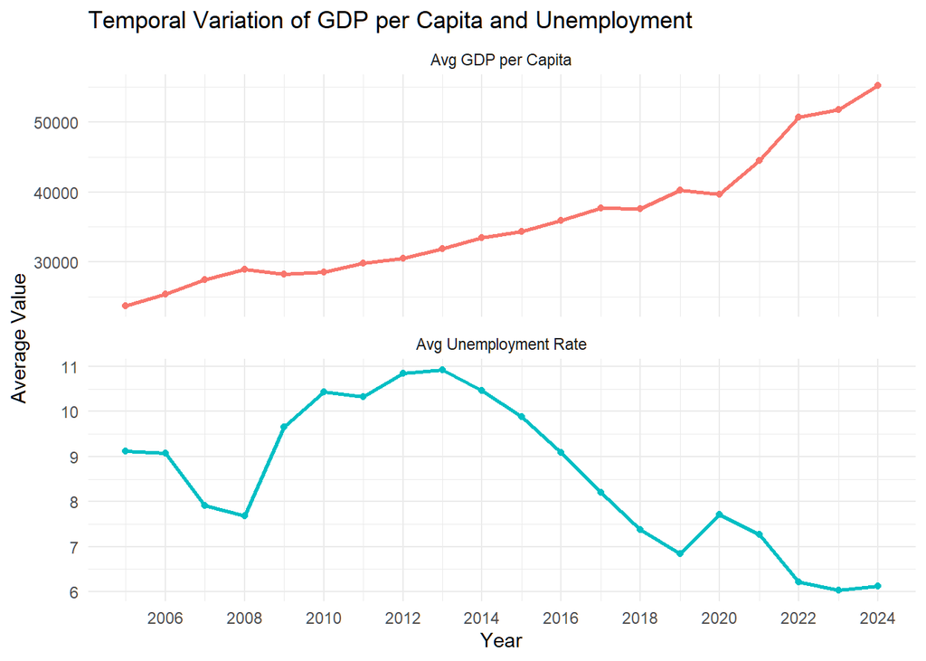

```r
library(ggplot2)
library(dplyr)

plot_data <- elasticity_table %>%
  group_by(PeriodCode) %>%
  summarise(
    # CHANGE 'Value.y' to whatever your actual GDP column is named
    `Avg GDP per Capita` = mean(Value.y, na.rm = TRUE),

    # CHANGE 'Value.x' to whatever your actual Unemployment column is named
    `Avg Unemployment Rate` = mean(Value.x, na.rm = TRUE)
  ) %>%
  tidyr::pivot_longer(
    cols = c(`Avg GDP per Capita`, `Avg Unemployment Rate`),
    names_to = "Metric",
    values_to = "Value"
  )

# 2. Plot
ggplot(plot_data, aes(x = PeriodCode, y = Value, color = Metric)) +
  geom_line(size = 1) +
  geom_point() +
  facet_wrap(~Metric, ncol = 1, scales = "free_y") +
  scale_x_continuous(breaks = seq(2004, 2024, by = 2)) +
  labs(
    title = "Temporal Variation of GDP per Capita and Unemployment",
    x = "Year",
    y = "Average Value"
  ) +
  theme_minimal() +
  theme(legend.position = "none")
```

## 3.4 Visualize spatial variation

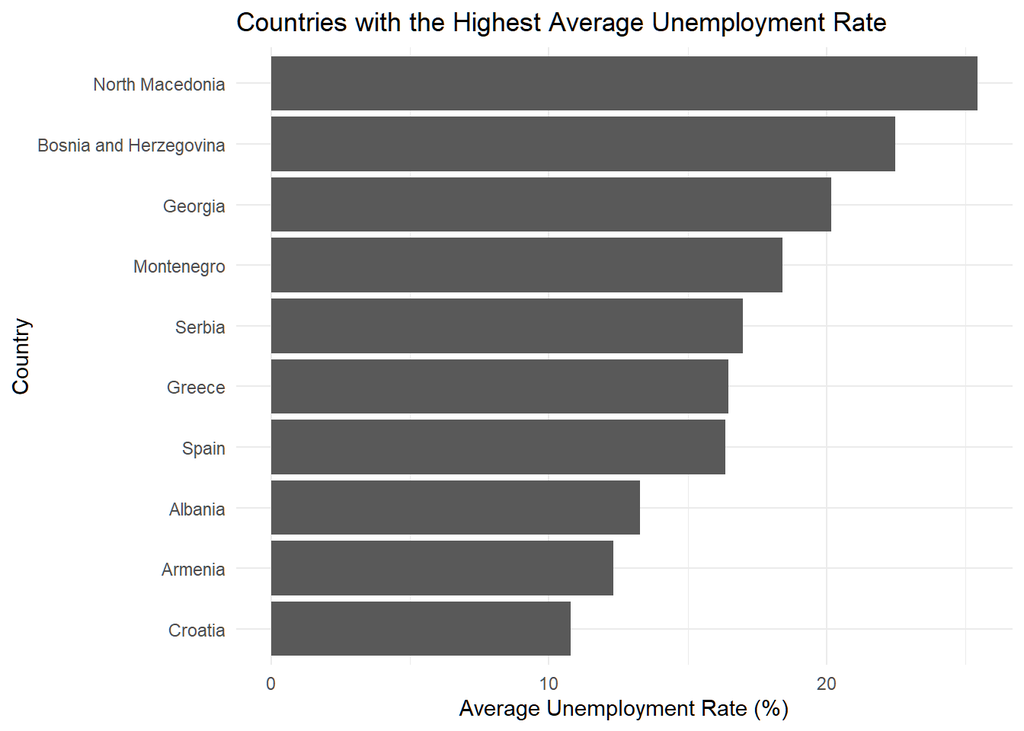

```r
library(dplyr)
library(ggplot2)

merged_data$Value.x <- as.numeric(merged_data$Value.x)
spatial_data <- merged_data %>%
  group_by(CountryName) %>%
  summarise(
    Avg_Unemployment = mean(Value.x, na.rm = TRUE)
  ) %>%
  arrange(desc(Avg_Unemployment)) %>%
  slice(1:10)

ggplot(
  spatial_data,
  aes(
    x = reorder(CountryName, Avg_Unemployment),
    y = Avg_Unemployment
  )
) +
  geom_col() +
  coord_flip() +
  labs(
    title = "Countries with the Highest Average Unemployment Rate",
    x = "Country",
    y = "Average Unemployment Rate (%)"
  ) +
  theme_minimal()
```

This figure shows the differences in unemployment rates between countries. We can see that unemployment is not the same everywhere. Countries such as North Macedonia, Bosnia and Herzegovina, and Georgia have much higher unemployment rates than other countries in the dataset. This is important for our social problem because high unemployment can lead to poverty, financial problems, and a lower quality of life. The graph shows that some countries are affected by unemployment much more than others.

## 3.5 Visualize sub-population variation

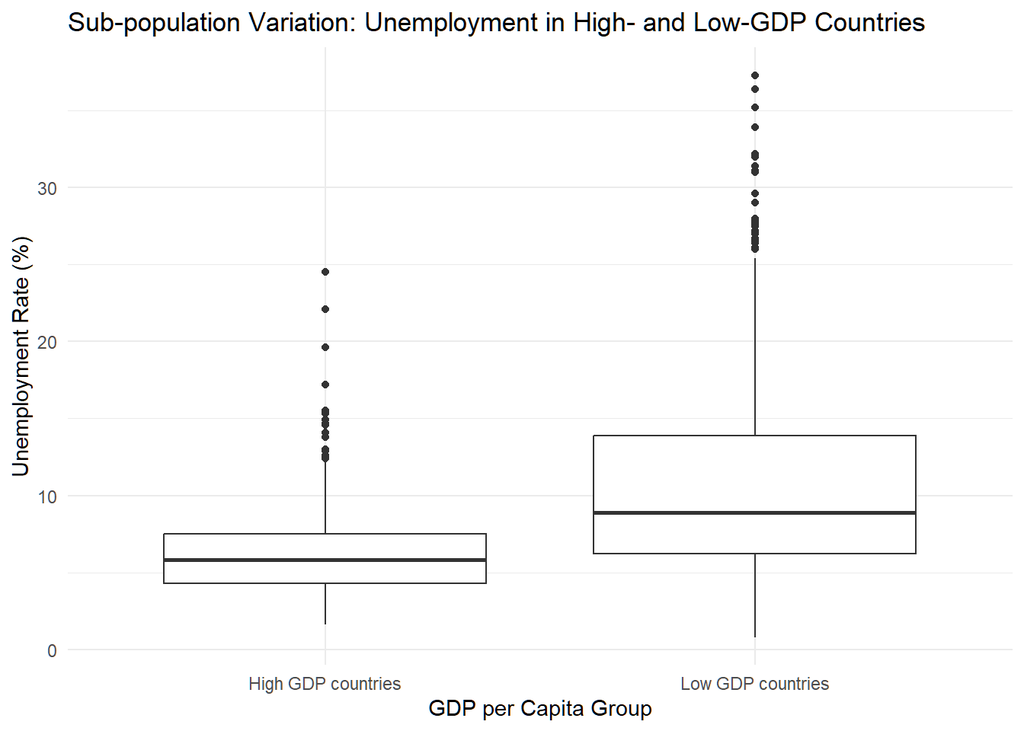

```r
boxplot_data <- elasticity_table %>%
  filter(!is.na(Value.y), !is.na(Value.x)) %>%
  mutate(
    GDP_Group = ifelse(
      Value.y >= median(Value.y, na.rm = TRUE),
      "High GDP countries",
      "Low GDP countries"
    )
  )

ggplot(boxplot_data, aes(x = GDP_Group, y = Value.x)) +
  geom_boxplot() +
  labs(
    title = "Sub-population Variation: Unemployment in High- and Low-GDP Countries",
    x = "GDP per Capita Group",
    y = "Unemployment Rate (%)"
  ) +
  theme_minimal()
```

This boxplot compares the distribution of unemployment rates between low-GDP and high-GDP countries. The countries are grouped based on whether their GDP per capita is below or above the median GDP per capita in the dataset.

The main purpose of the graph is to see whether unemployment rates differ between richer and poorer countries. If the box for low-GDP countries is higher, it suggests that countries with lower GDP per capita generally have higher unemployment. If the high-GDP box is lower, this suggests that wealthier countries may have more stable labour markets.

The line inside each box shows the median unemployment rate. The box itself shows the middle 50% of the observations. The lines extending from the box show the wider range of values, while individual dots represent possible outliers.

## 3.6 Event analysis

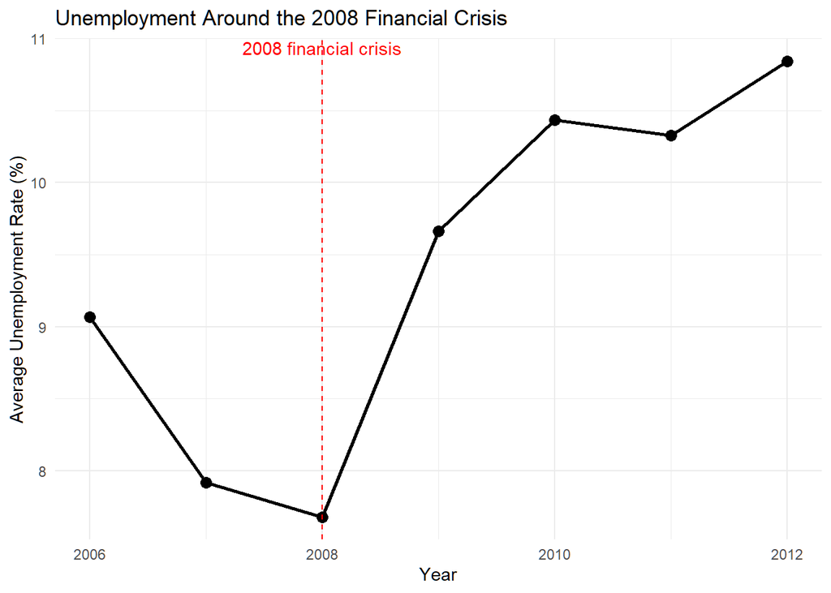

```r
library(dplyr)
library(ggplot2)

event_data <- merged_data %>%
  mutate(
    Value.x = as.numeric(as.character(Value.x)),
    PeriodCode = as.numeric(as.character(PeriodCode))
  ) %>%
  group_by(PeriodCode) %>%
  summarise(
    Avg_Unemployment = mean(Value.x, na.rm = TRUE)
  ) %>%
  filter(PeriodCode >= 2006 & PeriodCode <= 2012)

ggplot(event_data, aes(x = PeriodCode, y = Avg_Unemployment)) +
  geom_line(size = 1) +
  geom_point(size = 3) +
  geom_vline(xintercept = 2008, linetype = "dashed", color = "red") +
  annotate(
    "text",
    x = 2008,
    y = max(event_data$Avg_Unemployment, na.rm = TRUE),
    label = "2008 financial crisis",
    color = "red",
    vjust = -0.5
  ) +
  labs(
    title = "Unemployment Around the 2008 Financial Crisis",
    x = "Year",
    y = "Average Unemployment Rate (%)"
  ) +
  theme_minimal()
```

This figure shows the average unemployment rate around the 2008 financial crisis. After 2008, unemployment increased noticeably in the countries included in the dataset. This suggests that the crisis may have had a negative impact on employment. The figure is relevant because higher unemployment can lead to poverty, financial insecurity, and a lower quality of life.

# Part 4 - Discussion

## 4.1 Discuss your findings

Our analysis showed a generally negative relationship between GDP per capita and unemployment. Countries with a higher GDP per capita tended to have lower unemployment rates. We also observed that unemployment rates differed considerably between countries, with some countries consistently experiencing much higher unemployment than others. In addition, the 2008 financial crisis was followed by a noticeable increase in unemployment, suggesting that economic shocks can have a significant impact on labour markets. When GDP falls, economic activity decreases, causing firms to produce less and often reduce their workforce, which can lead to higher level of unemployment.

A limitation of this study is that we only analysed data at the national level. Regional differences within countries were not included, even though unemployment and economic development can vary strongly between regions. Future research could examine these regional differences to gain a more detailed understanding of the relationship between GDP and unemployment.

## 5.1 Github repository link

https://github.com/kdamen-lang/tutorial-groep-5-groepje-3.git

## 5.2 Reference list

Blanchard, O., Amighini, A., & Giavazzi, F. (2021).*Macroeconomics: a European perspective*(4th ed.) [Macroeconomics]. Pearson Education Limited.https://www.pearson.com/uk

*Gross domestic product (GDP) per capita - Data Portal - United Nations Economic Commission for Europe*. (n.d.-b).https://w3.unece.org/PXWeb/en/Table?IndicatorCode=12

Okun, A. M. (1962). Potential GNP: Its measurement and significance. *Proceedings of the Business and Economic Statistics Section of the American Statistical Association*, 98–104.

*Unemployment rate - Data Portal - United Nations Economic Commission for Europe*. (n.d.).https://w3.unece.org/PXWeb/en/Table?IndicatorCode=43